# Exploratory Data Analysis

Michal

2024-07-10

## Imports

```r
#knitr::purl("Data_Cleaning.Rmd", output = #"cleaning_function.R")
```

```r
source("cleaning_function.R")
uncleaned_bots = read.csv("C:/Users/Owner/Desktop/Data Science Project/Twitter-Bot-Code/archive/twitter_human_bots_dataset.csv")
```

## Data

```r
bots_cleaned = cleaning_function(uncleaned_bots)
head(bots_cleaned)
```

```
##            created_at default_profile default_profile_image
## 1 2009-07-04 22:41:51           FALSE                 FALSE
## 2 2010-01-17 22:54:19           FALSE                 FALSE
## 3 2012-03-01 06:05:32           FALSE                 FALSE
## 4 2009-09-01 04:52:30           FALSE                 FALSE
## 5 2010-01-27 17:17:23           FALSE                 FALSE
## 6 2017-06-17 05:45:14            TRUE                 FALSE
##                                                                                                                                    description
## 1
## 2                                                       Television producer. Emmy Award winner. Disney enthusiast. ZBB followers. Kitty crazy.
## 3
## 4
## 5 Productor de Televisión - Embajador de @TiendasEnForma y @NewLabNutrition Contacto: dream@davidhenaofilms.com \nInstagram: davidhenaofitness
## 6
##   geo_enabled           id lang        location     screen_name verified
```

[output cut: 20 more lines]

## Univariate Analysis

This section looks through the available columns and plots to introduce the data.

### Created At Date

Year

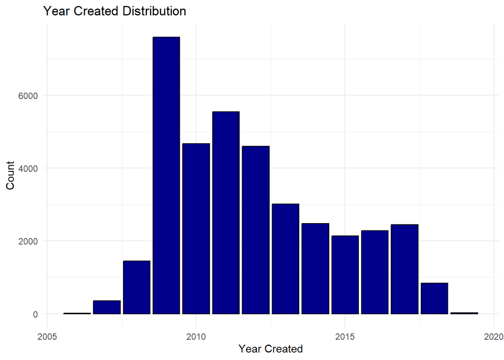

```r
ggplot(data = bots_cleaned, mapping = aes(year(created_at)))+
  geom_histogram(stat= "count", fill="darkblue", color = "black")+
  ggtitle("Year Created Distribution")+
  xlab("Year Created")+
  ylab("Count")+
  theme_minimal()
```

Month

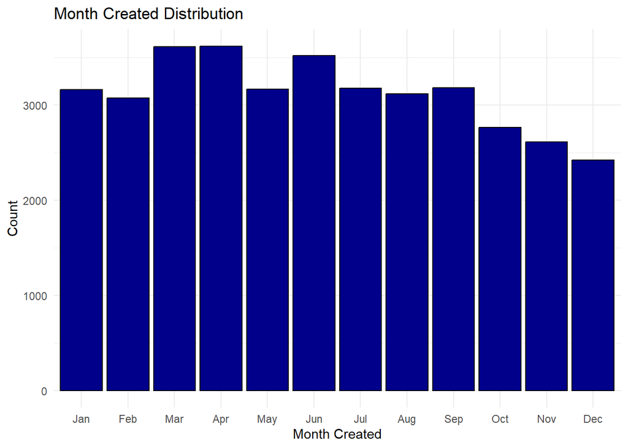

```r
ggplot(data = bots_cleaned, mapping = aes(month(created_at, label=TRUE)))+
  geom_histogram(stat= "count", fill="darkblue", color = "black")+
  ggtitle("Month Created Distribution")+
  xlab("Month Created")+
  ylab("Count")+
  theme_minimal()
```

Months in 2019

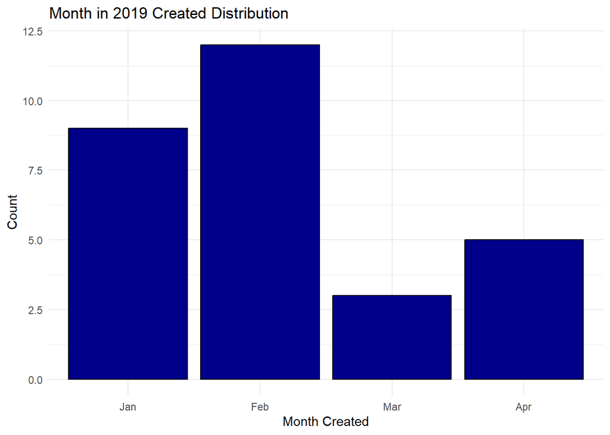

```r
ggplot(data = bots_cleaned%>%filter(year(created_at)== 2019), mapping = aes(month(created_at, label=TRUE)))+
  geom_histogram(stat= "count", fill="darkblue", color = "black")+
  ggtitle("Month in 2019 Created Distribution")+
  xlab("Month Created")+
  ylab("Count")+
  theme_minimal()
```

Weekday

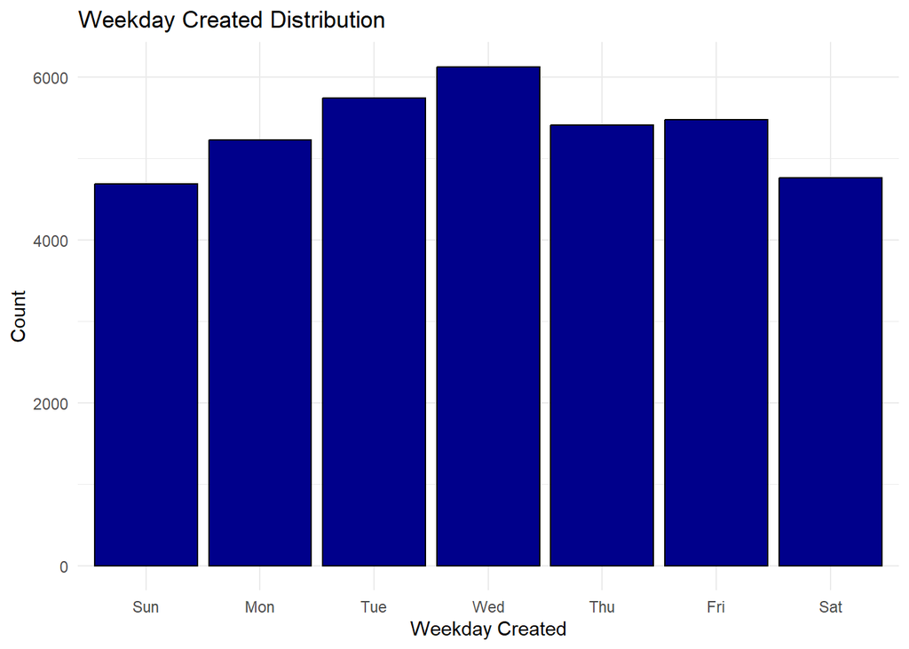

```r
ggplot(data = bots_cleaned, mapping = aes(wday(created_at, label=TRUE)))+
  geom_histogram(stat= "count", fill="darkblue", color = "black")+
  ggtitle("Weekday Created Distribution")+
  xlab("Weekday Created")+
  ylab("Count")+
  theme_minimal()
```

*Observations*

- The year created distribution is skewed right, with a peak in 2009.
- The monthly data is approximately uniform with slight spikes for March, April, and June, and a decrease towards the end of the year
- There 2019 data is only complete through April.
- There are slightly more accounts created on Wednesdays than the rest of the weekdays. The weekends have the least accounts created, but the difference is not large

### Default Profile

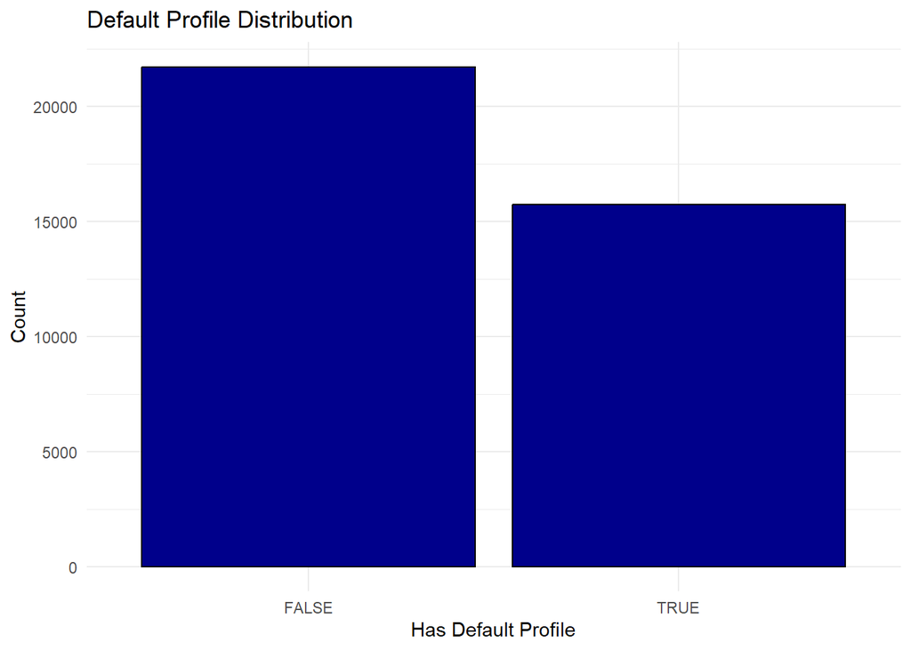

```r
ggplot(data = bots_cleaned, mapping = aes(default_profile))+
  geom_histogram(stat= "count", fill="darkblue", color = "black")+
  ggtitle("Default Profile Distribution")+
  xlab("Has Default Profile")+
  ylab("Count")+
  theme_minimal()
```

*Observations*

- Somewhat less than half of the accounts have default profiles

### Default Profile Image

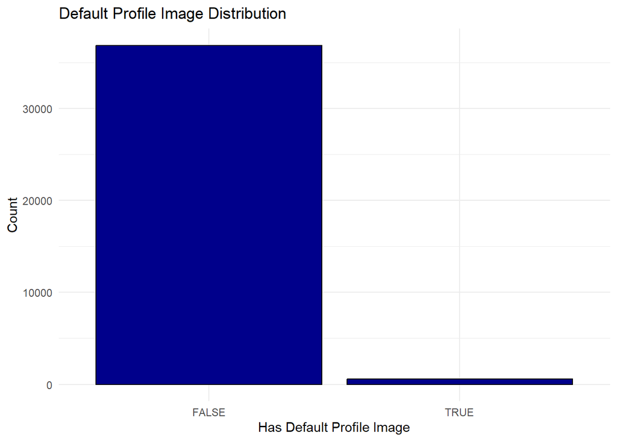

```r
ggplot(data = bots_cleaned, mapping = aes(default_profile_image))+
  geom_histogram(stat= "count", fill="darkblue", color = "black")+
  ggtitle("Default Profile Image Distribution")+
  xlab("Has Default Profile Image")+
  ylab("Count")+
  theme_minimal()
```

*Observations*

- Very few accounts have the default profile image

### Description

Has Description

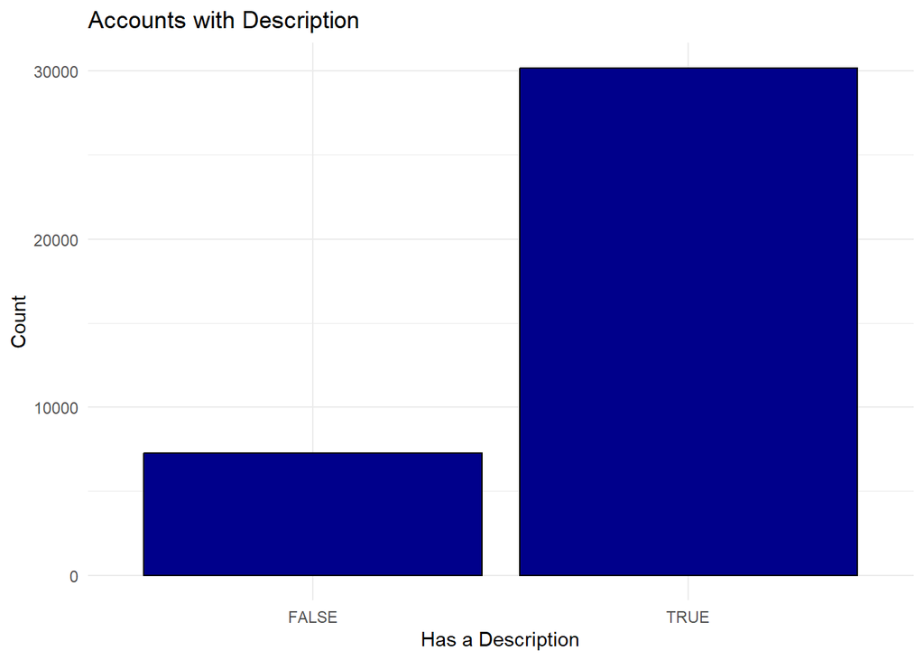

```r
ggplot(data = bots_cleaned, mapping = aes(str_length(description)!=0))+
  geom_histogram(stat="count",fill="darkblue", color = "black")+
  ggtitle("Accounts with Description")+
  xlab("Has a Description")+
  ylab("Count")+
  theme_minimal()
```

Description length

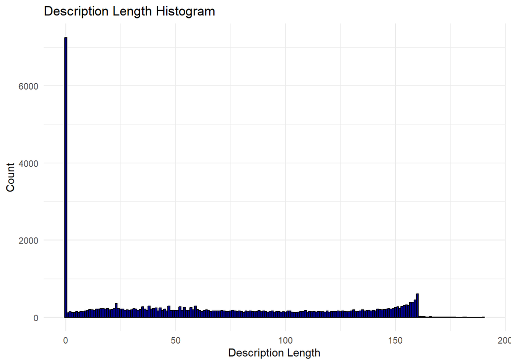

```r
ggplot(data = bots_cleaned, mapping = aes(str_length(description)))+
  geom_histogram(fill="darkblue", color = "black", binwidth = 1)+
  ggtitle("Description Length Histogram")+
  xlab("Description Length")+
  ylab("Count")+
  theme_minimal()
```

Description length excluding no description

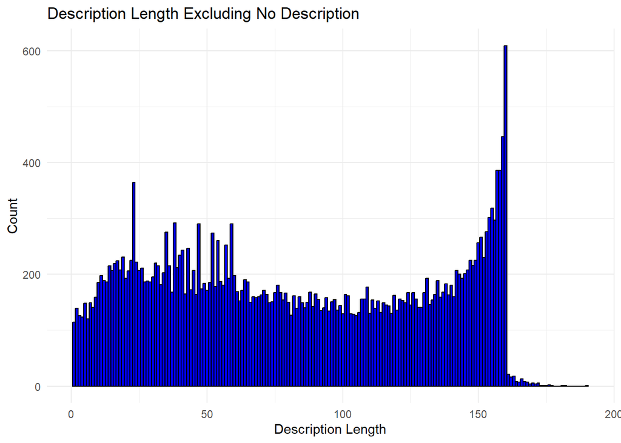

```r
ggplot(data = bots_cleaned%>%filter(str_length(description)!=0), mapping = aes(str_length(description)))+
  geom_histogram(fill="blue", color = "black", binwidth = 1)+
  ggtitle("Description Length Excluding No Description")+
  xlab("Description Length")+
  ylab("Count")+
  theme_minimal()
```

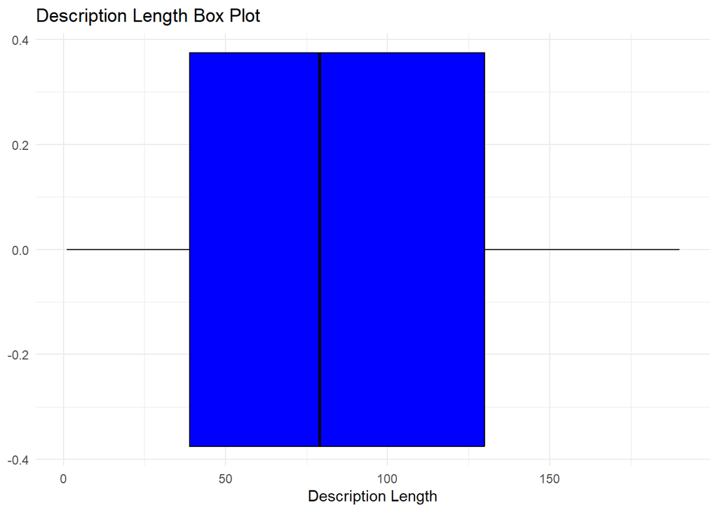

```r
ggplot(data = bots_cleaned%>%filter(str_length(description)!=0), mapping = aes(str_length(description)))+
  geom_boxplot(fill="blue", color = "black")+
  ggtitle("Description Length Box Plot")+
  xlab("Description Length")+
  theme(panel.background = element_rect(fill = "white"))+
  theme_minimal()
```

Number of spaces in description among accounts with description

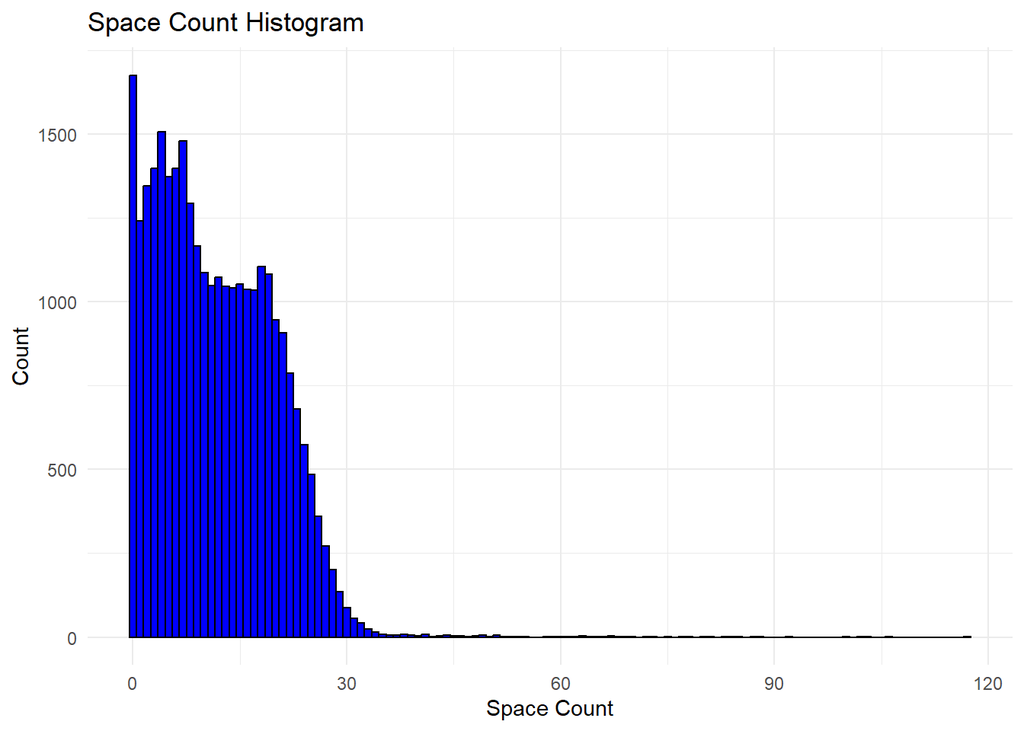

```r
ggplot(data = bots_cleaned%>%filter(description!=""), mapping = aes(str_count(description,"\\s")))+
  geom_histogram(fill="blue", color = "black", binwidth = 1)+
  ggtitle("Space Count Histogram")+
  xlab("Space Count")+
  ylab("Count")+
  theme_minimal()
```

Periods in Description (accounts with description)

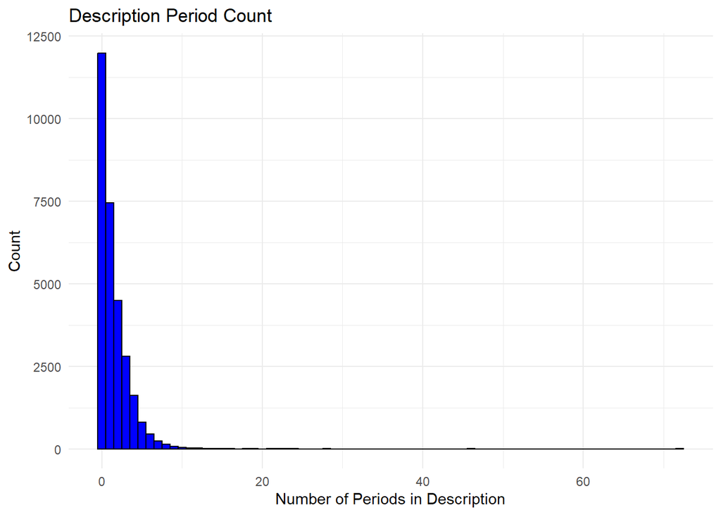

```r
ggplot(data = bots_cleaned%>%filter(description!=""), mapping = aes(str_count(description,"\\.")))+
  geom_histogram(fill="blue", color = "black", binwidth = 1)+
  ggtitle("Description Period Count")+
  xlab("Number of Periods in Description")+
  ylab("Count")+
  theme_minimal()
```

Punctuation in Description (accounts with description)

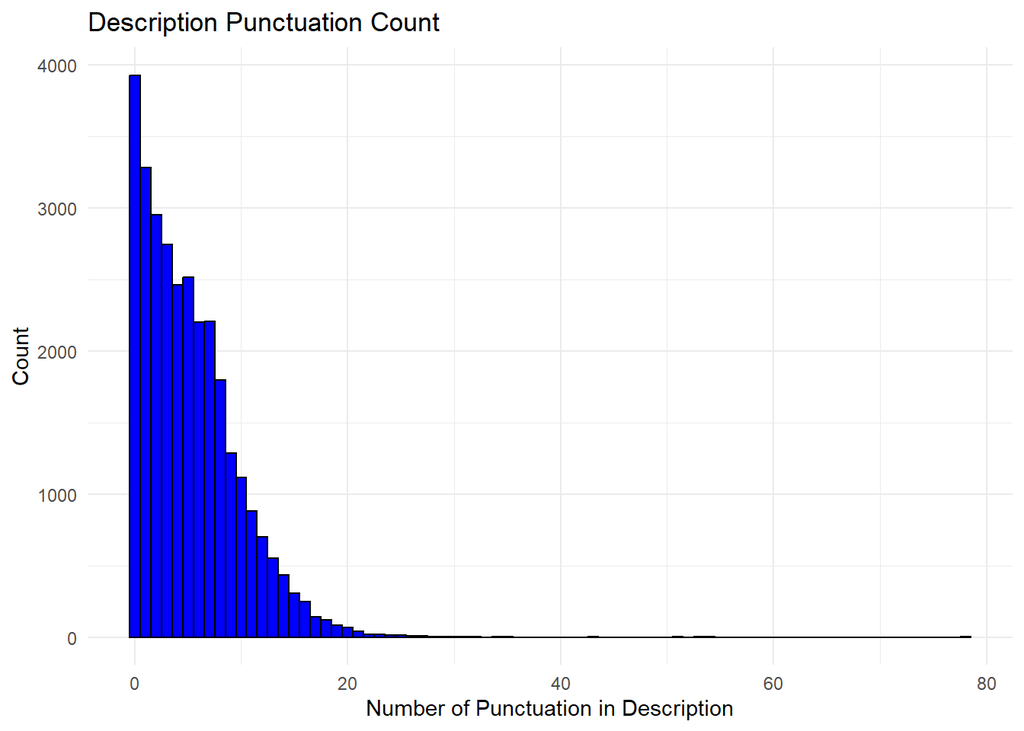

```r
ggplot(data = bots_cleaned%>%filter(description!=""), mapping = aes(str_count(description,"[:punct:]")))+
  geom_histogram(fill="blue", color = "black", binwidth = 1)+
  ggtitle("Description Punctuation Count")+
  xlab("Number of Punctuation in Description")+
  ylab("Count")+
  theme_minimal()
```

*Observations*

- Most accounts have a description, but a significant minority do not
- There is a somewhat bimodal distribution of description length, with peaks around 25 and 160 characters
- Space count, Period count, and Punctuation count is skewed right with a peak at 0

### Geography Enabled

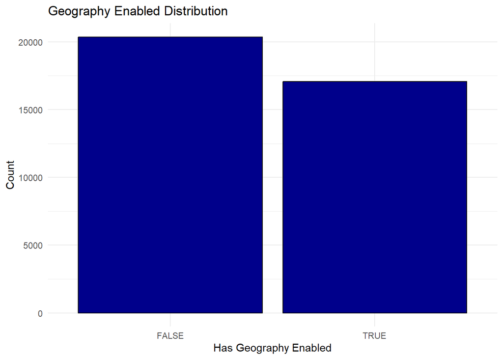

```r
ggplot(data = bots_cleaned, mapping = aes(geo_enabled))+
  geom_histogram(stat= "count", fill="darkblue", color = "black")+
  ggtitle("Geography Enabled Distribution")+
  xlab("Has Geography Enabled")+
  ylab("Count")+
  theme_minimal()
```

*Observations*

- A slight majority of accounts do not have geography enabled

### id

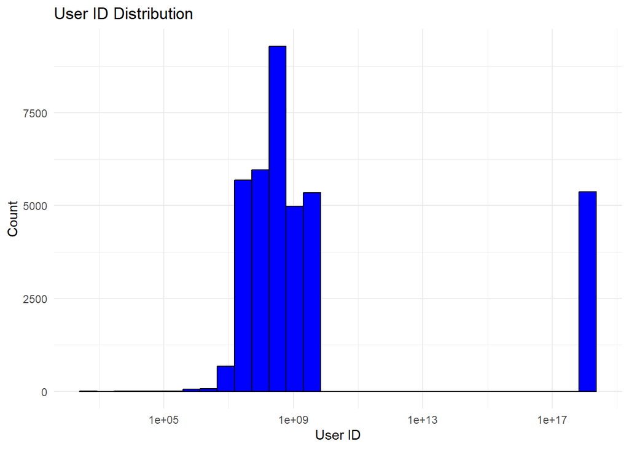

```r
ggplot(data = bots_cleaned, mapping = aes(id))+
  geom_histogram(fill="blue", color = "black")+
  ggtitle("User ID Distribution")+
  xlab("User ID")+
  ylab("Count")+
  scale_x_log10()+
  theme_minimal()
```

*Observations*

- Id values are strongly skewed right

### Language

```r
lang_count=bots_cleaned%>%
  count(lang)%>%
  slice_max(n,n=2)
lang_count
```

```
##   lang     n
## 1   en 21450
## 2       7957
```

```r
rest=bots_cleaned%>%
  count(lang)%>%
  anti_join(lang_count)%>%
  summarise(sum(n))
rest
```

```
##   sum(n)
## 1   8031
```

```r
final=bind_rows(lang_count,rest)%>%
  mutate(lang=if_else(lang=="", "None", lang))%>%
  mutate(lang=if_else(is.na(lang), "Other", lang))%>%
  mutate(n=if_else(is.na(n), 0, n))%>%
  mutate(`sum(n)`=if_else(is.na(`sum(n)`), 0, `sum(n)`))%>%
  mutate(n=n+`sum(n)`)%>%
  select(-`sum(n)`)
final
```

```
##    lang     n
## 1    en 21450
## 2  None  7957
## 3 Other  8031
```

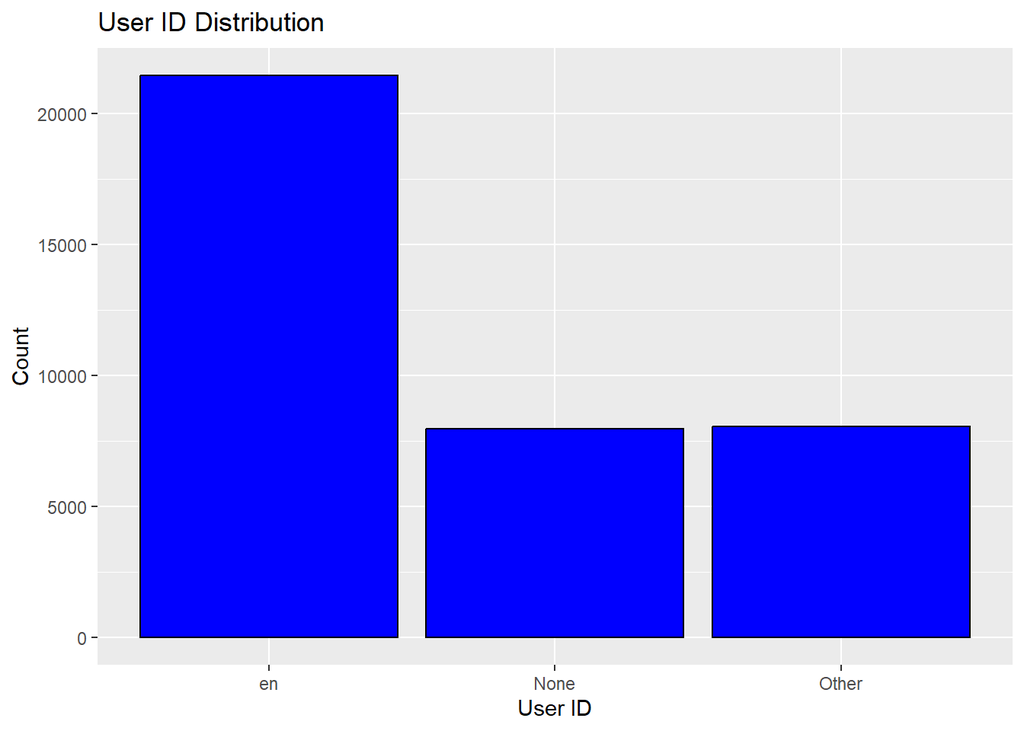

```r
ggplot(data = final, mapping = aes(x=lang,y=n))+
  geom_bar(stat = "identity",fill="blue", color = "black")+
  ggtitle("User ID Distribution")+
  xlab("User ID")+
  ylab("Count")
```

*Observations*

- The majority of accounts are in English, of the rest, half have no language set and half use another language

### Location

```r
top_30 = bots_cleaned%>%
  count(location)%>%
  slice_max(n,n=31)
top_30
```

```
##             location     n
## 1            unknown 13040
## 2    Los Angeles, CA   524
## 3       New York, NY   339
## 4      United States   239
## 5        Los Angeles   224
## 6     Washington, DC   224
## 7           New York   151
## 8        Chicago, IL   142
## 9             London   142
## 10   California, USA   138
## 11               USA   128
## 12   London, England   123
## 13     New York City   108
## 14               NYC   105
```

[output cut: 17 more lines]

```r
# 13040 unkown accounts
sum(top_30$n)-13040
```

```
## [1] 4003
```

```r
top_100 = bots_cleaned%>%
  count(location)%>%
  slice_max(n,n=101)
sum(top_100$n)-13040
```

```
## [1] 6681
```

```r
top_1000 = bots_cleaned%>%
  count(location)%>%
  slice_max(n,n=1001)
sum(top_1000$n)-13040
```

```
## [1] 12687
```

```r
a = bots_cleaned%>%
  count(location)
nrow(a)
```

```
## [1] 12045
```

*Observations*

### Username

Username length

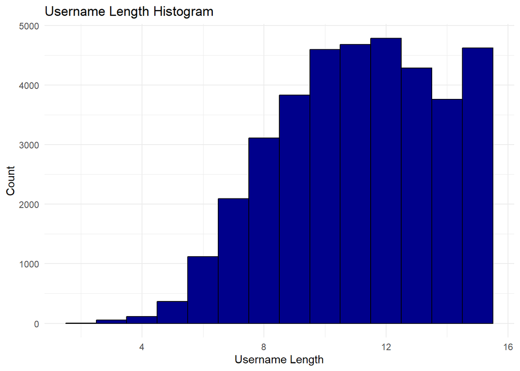

```r
ggplot(data = bots_cleaned, mapping = aes(str_length(screen_name)))+
  geom_histogram(fill="darkblue", color = "black", binwidth = 1)+
  ggtitle("Username Length Histogram")+
  xlab("Username Length")+
  ylab("Count")+
  theme_minimal()
```

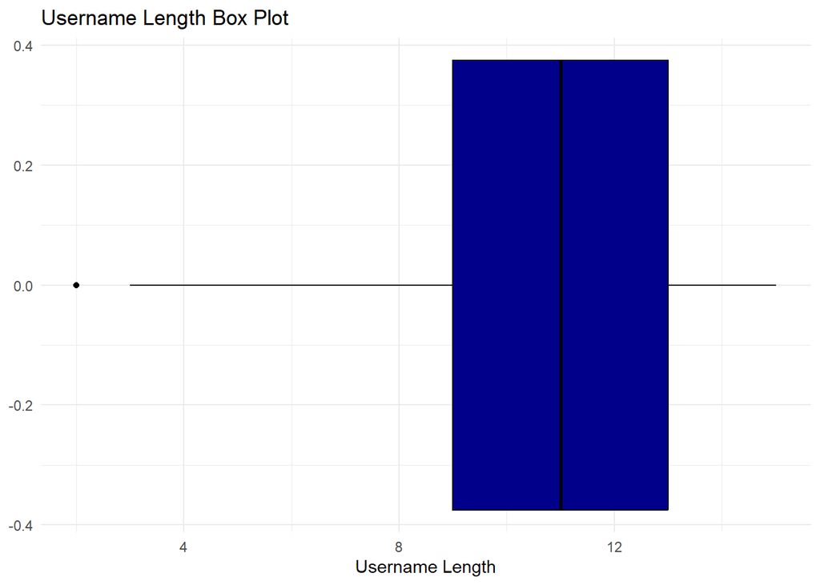

```r
ggplot(data = bots_cleaned, mapping = aes(str_length(screen_name)))+
  geom_boxplot(fill="darkblue", color = "black")+
  ggtitle("Username Length Box Plot")+
  xlab("Username Length")+
  theme(panel.background = element_rect(fill = "white"))+
  theme_minimal()
```

```r
summary(str_length(bots_cleaned$screen_name))
```

```
##    Min. 1st Qu.  Median    Mean 3rd Qu.    Max.
##    2.00    9.00   11.00   11.11   13.00   15.00
```

Digits in Username

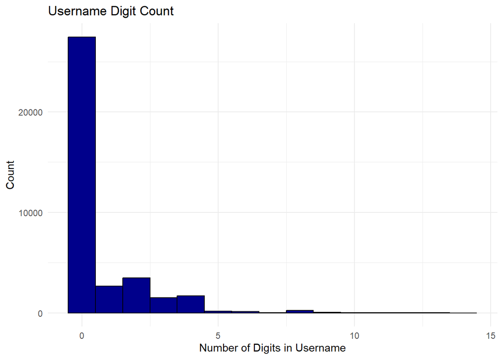

```r
ggplot(data = bots_cleaned, mapping = aes(str_count(screen_name,"\\d")))+
  geom_histogram(fill="darkblue", color = "black", binwidth = 1)+
  ggtitle("Username Digit Count")+
  xlab("Number of Digits in Username")+
  ylab("Count")+
  theme_minimal()
```

Digits in Username without zero

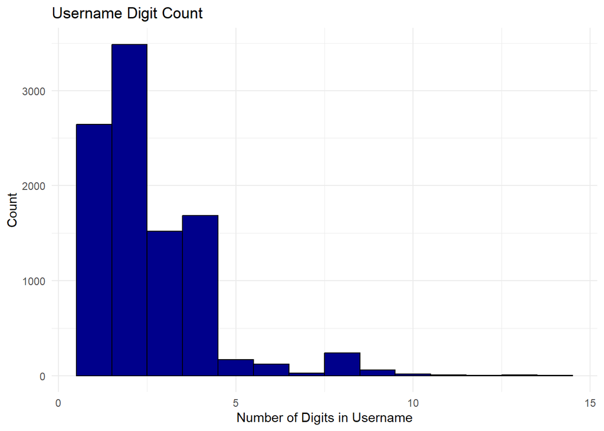

```r
ggplot(data = bots_cleaned%>%filter(str_count(screen_name,"\\d")!=0), mapping = aes(str_count(screen_name,"\\d")))+
  geom_histogram(fill="darkblue", color = "black", binwidth = 1)+
  ggtitle("Username Digit Count")+
  xlab("Number of Digits in Username")+
  ylab("Count")+
  theme_minimal()
```

*Observations*

- Username length is strongly skewed to the left, with a maximum at 15 characters
- The majority of Usernames contain zero digits
- Among usernames with digits, there is a right skew, with a peak at 2 digits

### Verified

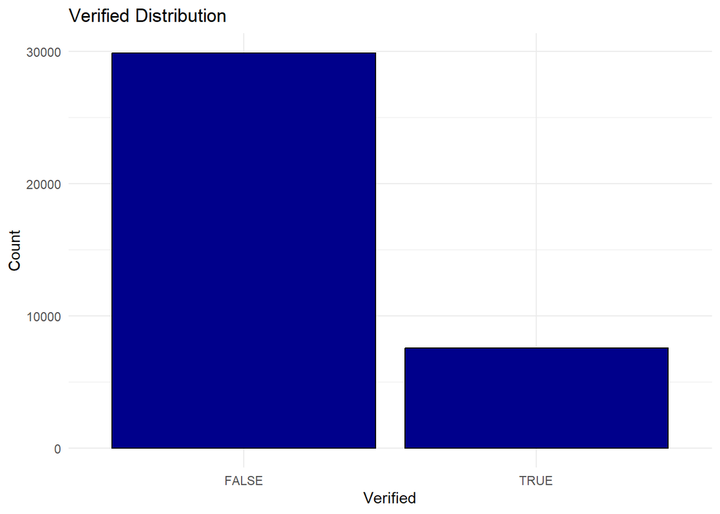

```r
ggplot(data = bots_cleaned, mapping = aes(verified))+
  geom_histogram(stat= "count", fill="darkblue", color = "black")+
  ggtitle("Verified Distribution")+
  xlab("Verified")+
  ylab("Count")+
  theme_minimal()
```

*Observations*

- Under one quarter of the Twitter accounts are verified

### Account Age

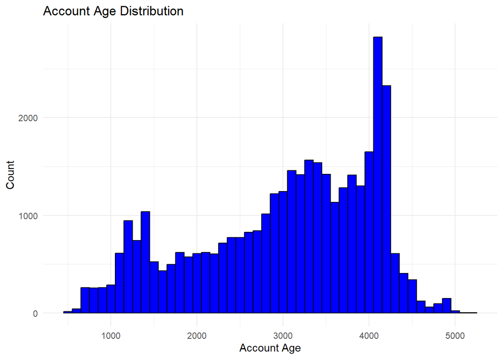

```r
ggplot(data = bots_cleaned, mapping = aes(account_age_days))+
  geom_histogram(fill="blue", color = "black", binwidth = 100)+
  ggtitle("Account Age Distribution")+
  xlab("Account Age")+
  ylab("Count")+
  theme_minimal()
```

*Observations*

- Account age is skewed left with a peak around 4100 days

### Bot Label

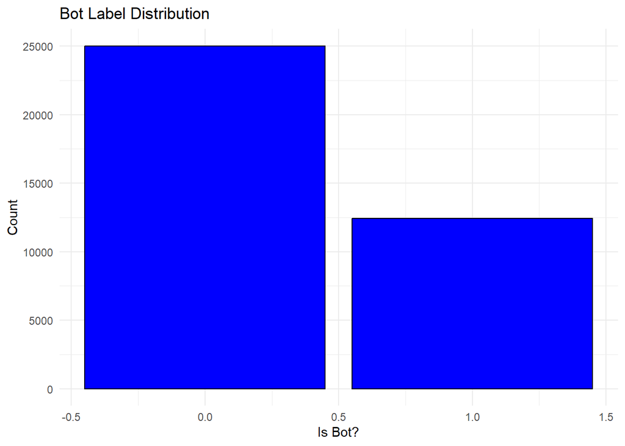

```r
ggplot(data = bots_cleaned, mapping = aes(is_bot))+
  geom_bar(fill="blue", color = "black")+
  ggtitle("Bot Label Distribution")+
  xlab("Is Bot?")+
  ylab("Count")+
  theme_minimal()
```

*Observations*

- Around one third of the Twitter accounts in this data set are bots

### Split

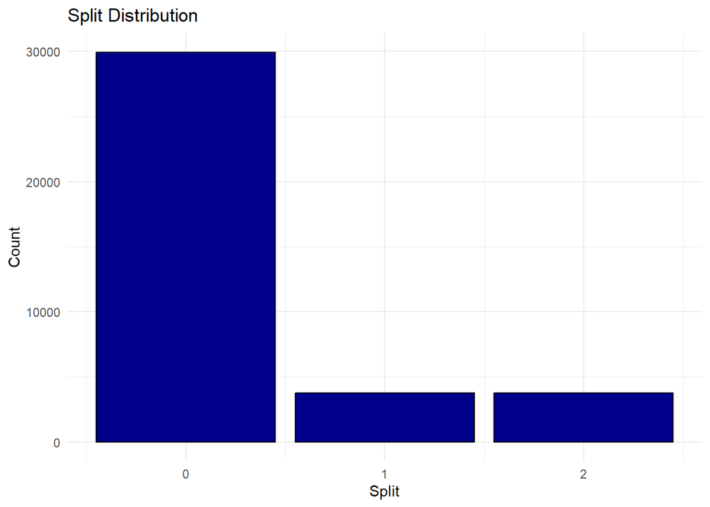

```r
ggplot(data = bots_cleaned, mapping = aes(split))+
  geom_bar(fill="darkblue", color = "black")+
  ggtitle("Split Distribution")+
  xlab("Split")+
  ylab("Count")+
  theme_minimal()
```

*Observations*

- Almost all split values are 0, with the rest being equally distributed between 1 and 2

### Favourites Count

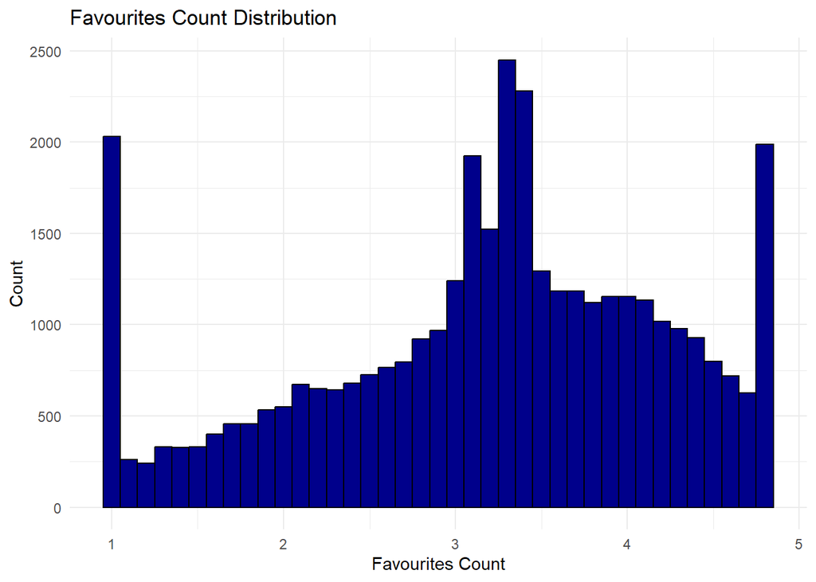

```r
ggplot(data = bots_cleaned, mapping = aes(log_favourites_count))+
  geom_histogram(fill="darkblue", color = "black", binwidth = .1)+
  ggtitle("Favourites Count Distribution")+
  xlab("Favourites Count")+
  ylab("Count")+
  theme_minimal()
```

*Observations*

- The transformed and winsorized favorites count is skewed left with a sharp peak around 3.2

### Followers Count

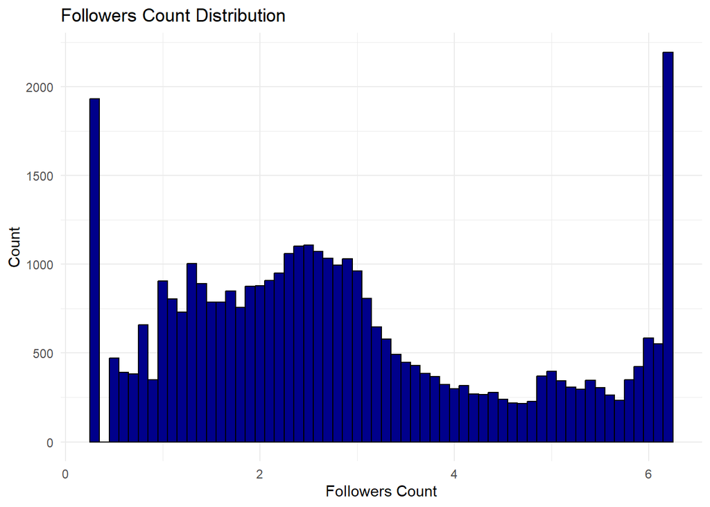

```r
ggplot(data = bots_cleaned, mapping = aes(log_followers_count))+
  geom_histogram(fill="darkblue", color = "black", binwidth = .1)+
  ggtitle("Followers Count Distribution")+
  xlab("Followers Count")+
  ylab("Count")+
  theme_minimal()
```

*Observations*

- The transformed and winsorized followers count is non-normal and skewed right

### Friends Count

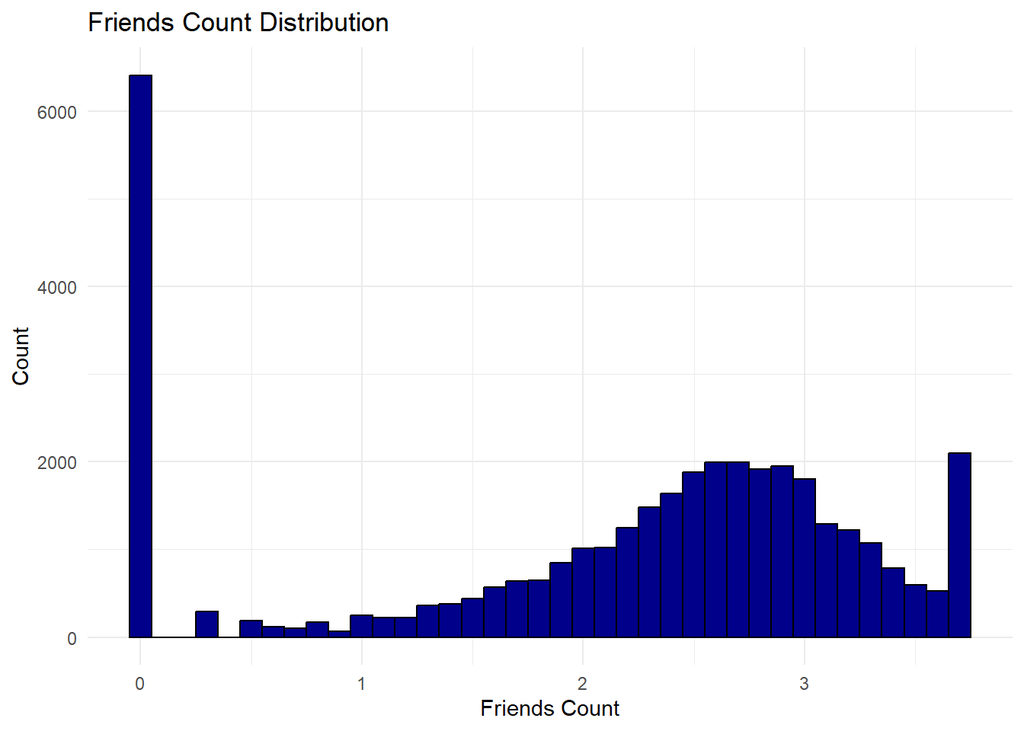

```r
ggplot(data = bots_cleaned, mapping = aes(log_friends_count))+
  geom_histogram(fill="darkblue", color = "black", binwidth = .1)+
  ggtitle("Friends Count Distribution")+
  xlab("Friends Count")+
  ylab("Count")+
  theme_minimal()
```

*Observations*

- The transformed and winsorized friends count is non-normal and skewed left

### Statuses Count

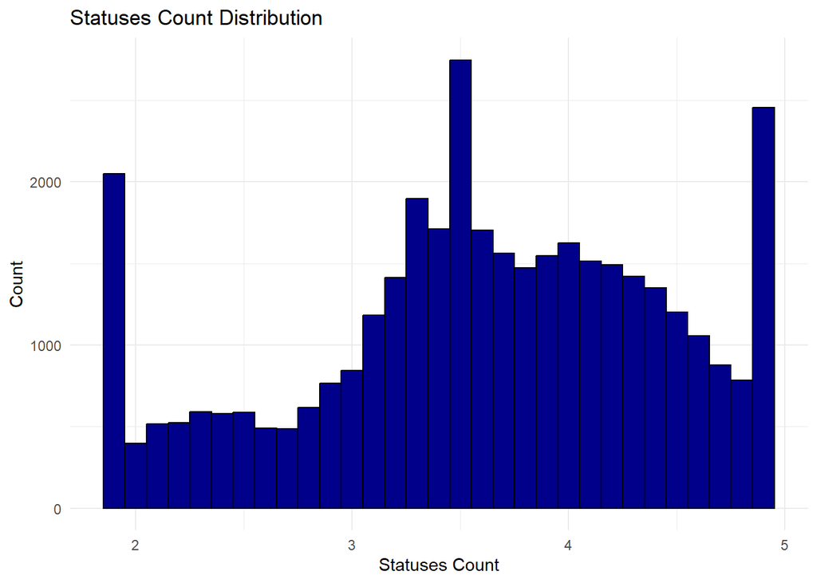

```r
ggplot(data = bots_cleaned, mapping = aes(log_statuses_count))+
  geom_histogram(fill="darkblue", color = "black", binwidth = .1)+
  ggtitle("Statuses Count Distribution")+
  xlab("Statuses Count")+
  ylab("Count")+
  theme_minimal()
```

*Observations*

- The transformed and winsorized statuses count is non-normal and skewed left

### Average Tweets Per Day

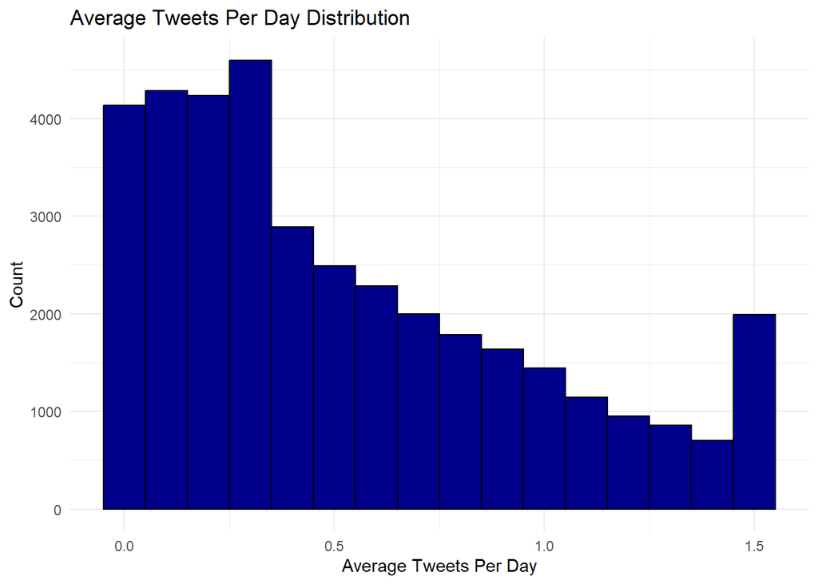

```r
ggplot(data = bots_cleaned, mapping = aes(log_avg_tweets_per_day))+
  geom_histogram(fill="darkblue", color = "black", binwidth = .1)+
  ggtitle("Average Tweets Per Day Distribution")+
  xlab("Average Tweets Per Day")+
  ylab("Count")+
  theme_minimal()
```

*Observations*

- The transformed and winsorized Average Tweets Per Day count is non-normal and skewed right

## Features vs Target

This section performs a bi-variate analysis of the distribution of Bot accounts. This can help in determining what data and feature selection to perform.

### Geography Enabled

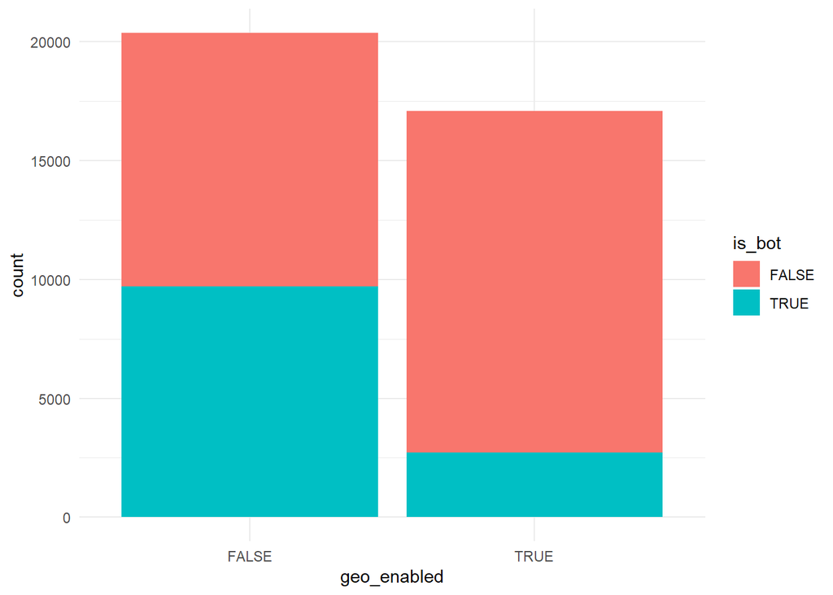

```r
ggplot(data = bots_cleaned%>%mutate(is_bot=as.logical(is_bot)), mapping = aes(x=geo_enabled, fill = is_bot))+
  geom_bar()+
  theme_minimal()
```

```r
summary_table <- bots_cleaned %>%
  group_by(geo_enabled, is_bot) %>%
  summarize(count = n())
summary_table
```

```
## # A tibble: 4 × 3
## # Groups:   geo_enabled [2]
##   geo_enabled is_bot count
##   <lgl>        <dbl> <int>
## 1 FALSE            0 10652
## 2 FALSE            1  9709
## 3 TRUE             0 14361
## 4 TRUE             1  2716
```

```r
test_result <- prop.test(
  x = c(2716, 9709),
  n = c(2716+14361, 9709+10652)
)
test_result
```

```
##
##  2-sample test for equality of proportions with continuity correction
##
## data:  c(2716, 9709) out of c(2716 + 14361, 9709 + 10652)
## X-squared = 4228.8, df = 1, p-value < 2.2e-16
## alternative hypothesis: two.sided
## 95 percent confidence interval:
##  -0.3266361 -0.3089612
## sample estimates:
##    prop 1    prop 2
## 0.1590443 0.4768430
```

*Observations*

- There is a significantly higher proportion of bots among the accounts with geography disabled (p-value < 2.2e-16)

*Impact*

- geo_enabled is a strong predictor of whether the account is a bot

### Verified

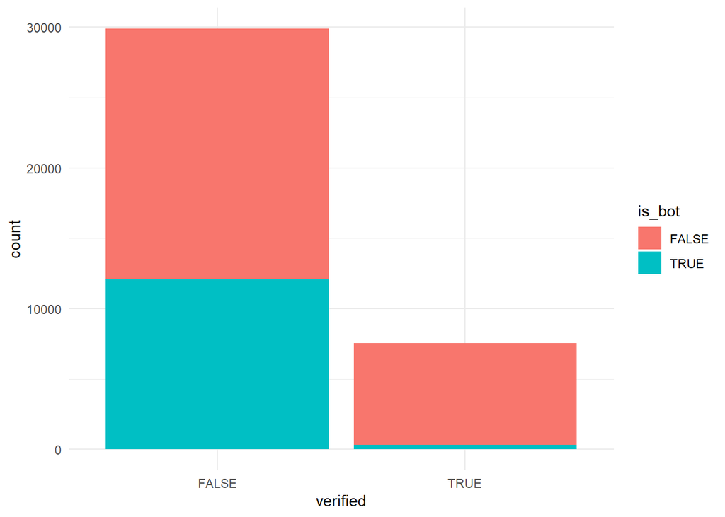

```r
ggplot(data = bots_cleaned%>%mutate(is_bot=as.logical(is_bot)), mapping = aes(x=verified, fill = is_bot))+
  geom_bar()+
  theme_minimal()
```

```r
summary_table2 <- bots_cleaned %>%
  group_by(verified, is_bot) %>%
  summarize(count = n())
summary_table2
```

```
## # A tibble: 4 × 3
## # Groups:   verified [2]
##   verified is_bot count
##   <lgl>     <dbl> <int>
## 1 FALSE         0 17778
## 2 FALSE         1 12109
## 3 TRUE          0  7235
## 4 TRUE          1   316
```

```r
test_result2 <- prop.test(
  x = c(12109, 316),
  n = c(17778+12109, 7235+316)
)
test_result2
```

```
##
##  2-sample test for equality of proportions with continuity correction
##
## data:  c(12109, 316) out of c(17778 + 12109, 7235 + 316)
## X-squared = 3586.7, df = 1, p-value < 2.2e-16
## alternative hypothesis: two.sided
## 95 percent confidence interval:
##  0.3560600 0.3705613
## sample estimates:
##     prop 1     prop 2
## 0.40515943 0.04184876
```

*Observations*

- There is a significantly higher proportion of bots among the accounts that are not verified (p-value < 2.2e-16)

*Impact*

- verified is a significant predictor of whether the account is a bot

### Default Profile

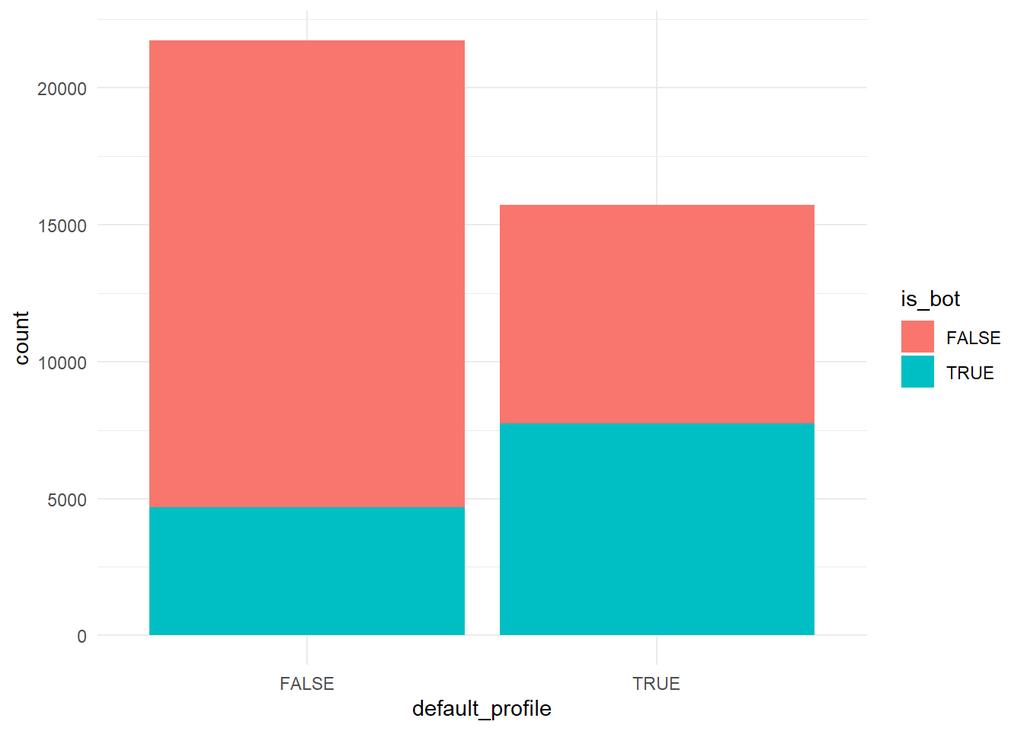

```r
ggplot(data = bots_cleaned%>%mutate(is_bot=as.logical(is_bot)), mapping = aes(x=default_profile, fill = is_bot))+
  geom_bar()+
  theme_minimal()
```

```r
summary_table3 <- bots_cleaned %>%
  group_by(default_profile, is_bot) %>%
  summarize(count = n())
summary_table3
```

```
## # A tibble: 4 × 3
## # Groups:   default_profile [2]
##   default_profile is_bot count
##   <lgl>            <dbl> <int>
## 1 FALSE                0 17034
## 2 FALSE                1  4684
## 3 TRUE                 0  7979
## 4 TRUE                 1  7741
```

```r
test_result3 <- prop.test(
  x = c(7741, 4684),
  n = c(7979+7741, 17034+4684)
)
test_result3
```

```
##
##  2-sample test for equality of proportions with continuity correction
##
## data:  c(7741, 4684) out of c(7979 + 7741, 17034 + 4684)
## X-squared = 3148.8, df = 1, p-value < 2.2e-16
## alternative hypothesis: two.sided
## 95 percent confidence interval:
##  0.2671622 0.2863505
## sample estimates:
##    prop 1    prop 2
## 0.4924300 0.2156736
```

*Observations*

- There is a significantly higher proportion of bots among the accounts that use the default profile (p-value < 2.2e-16)

*Impact*

- Default profile is a significant predictor of whether the account is a bot

### Default Profile Image

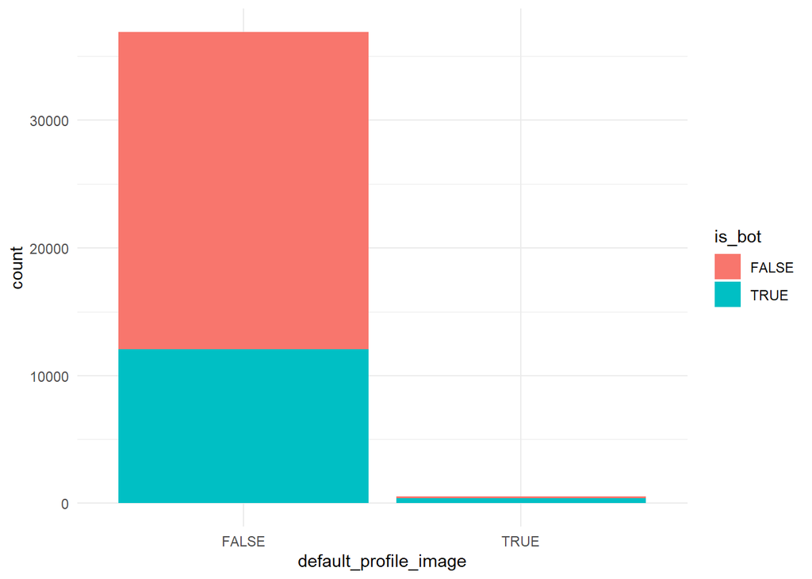

```r
ggplot(data = bots_cleaned%>%mutate(is_bot=as.logical(is_bot)), mapping = aes(x=default_profile_image, fill = is_bot))+
  geom_bar()+
  theme_minimal()
```

```r
summary_table4 <- bots_cleaned %>%
  group_by(default_profile_image, is_bot) %>%
  summarize(count = n())
summary_table4
```

```
## # A tibble: 4 × 3
## # Groups:   default_profile_image [2]
##   default_profile_image is_bot count
##   <lgl>                  <dbl> <int>
## 1 FALSE                      0 24838
## 2 FALSE                      1 12042
## 3 TRUE                       0   175
## 4 TRUE                       1   383
```

```r
test_result4 <- prop.test(
  x = c(383, 12042),
  n = c(383+175, 12042+24838)
)
test_result4
```

```
##
##  2-sample test for equality of proportions with continuity correction
##
## data:  c(383, 12042) out of c(383 + 175, 12042 + 24838)
## X-squared = 319.41, df = 1, p-value < 2.2e-16
## alternative hypothesis: two.sided
## 95 percent confidence interval:
##  0.3201595 0.3995634
## sample estimates:
##    prop 1    prop 2
## 0.6863799 0.3265184
```

*Observations*

- There is a significantly higher proportion of bots among the accounts that are use the default profile image (p-value < 2.2e-16)

*Impact*

- Default profile image is a significant predictor of whether the account is a bot

### Split

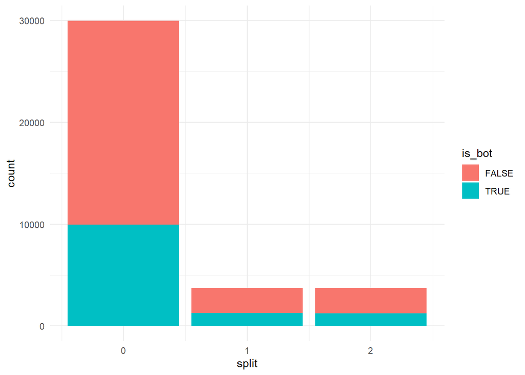

```r
ggplot(data = bots_cleaned%>%mutate(is_bot=as.logical(is_bot)), mapping = aes(x=split, fill = is_bot))+
  geom_bar()+
  theme_minimal()
```

```r
summary_table5 <- bots_cleaned %>%
  group_by(split, is_bot) %>%
  summarize(count = n())
summary_table5
```

```
## # A tibble: 6 × 3
## # Groups:   split [3]
##   split is_bot count
##   <int>  <dbl> <int>
## 1     0      0 20018
## 2     0      1  9932
## 3     1      0  2476
## 4     1      1  1267
## 5     2      0  2519
## 6     2      1  1226
```

```r
# split 0 vs split 1
test_result5a <- prop.test(
  x = c(9932, 1267),
  n = c(9932+20018, 1267+2476)
)
test_result5a
```

```
##
##  2-sample test for equality of proportions with continuity correction
##
## data:  c(9932, 1267) out of c(9932 + 20018, 1267 + 2476)
## X-squared = 0.67889, df = 1, p-value = 0.41
## alternative hypothesis: two.sided
## 95 percent confidence interval:
##  -0.02309918  0.00934085
## sample estimates:
##    prop 1    prop 2
## 0.3316194 0.3384985
```

```r
# split 1 vs split 2
test_result5b <- prop.test(
  x = c(1226, 1267),
  n = c(1226+2519, 1267+2476)
)
test_result5b
```

```
##
##  2-sample test for equality of proportions with continuity correction
##
## data:  c(1226, 1267) out of c(1226 + 2519, 1267 + 2476)
## X-squared = 0.99442, df = 1, p-value = 0.3187
## alternative hypothesis: two.sided
## 95 percent confidence interval:
##  -0.03274241  0.01048500
## sample estimates:
##    prop 1    prop 2
## 0.3273698 0.3384985
```

```r
# split 0 vs split 2
test_result5c <- prop.test(
  x = c(1226, 9932),
  n = c(1226+2519, 9932+20018)
)
test_result5c
```

```
##
##  2-sample test for equality of proportions with continuity correction
##
## data:  c(1226, 9932) out of c(1226 + 2519, 9932 + 20018)
## X-squared = 0.25256, df = 1, p-value = 0.6153
## alternative hypothesis: two.sided
## 95 percent confidence interval:
##  -0.02034652  0.01184744
## sample estimates:
##    prop 1    prop 2
## 0.3273698 0.3316194
```

*Observations*

- There is a no significant difference of proportion of bots among the accounts based on split value (p-value = 0.6153, 0.3187, and 0.41)

*Impact*

- Data set can be filtered out to exclude split because it is not a significant predictor of whether the account is a bot

## Hypothesis

### Are younger accounts with more tweets per day more likely to be bots?

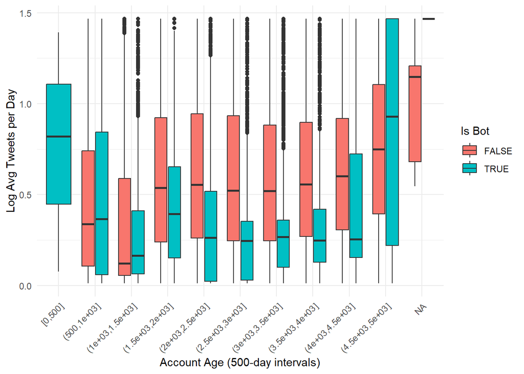

```r
ggplot(data = bots_cleaned%>%mutate(is_bot=as.logical(is_bot)), mapping = aes(x=cut(account_age_days, breaks = seq(0, max(account_age_days), by = 500), include.lowest = TRUE), y=log_avg_tweets_per_day, fill = is_bot))+
  geom_boxplot()+
  theme_minimal() +
  labs(x = "Account Age (500-day intervals)", y = "Log Avg Tweets per Day", fill = "Is Bot") +
  theme(axis.text.x = element_text(angle = 45, hjust = 1))
```

```r
thing = bots_cleaned%>%
  filter(account_age_days<=500)
thing$is_bot
```

```
## [1] 1 1 1
```

*Observations*

- The very oldest accounts do post more per day than the more recent ones
- Overall, bot accounts appear to post less than real accounts
- All (three) bots that are less than 500 days old are bots

*Insights*

- Filter data set to remove bots less than 500 days old
- Younger bots with more tweets per day are not more likely to be bots

### Are account activity data significant predictors of bots?

```r
activity_model = glm(is_bot ~ log_favourites_count+log_followers_count+log_friends_count+log_statuses_count+log_avg_tweets_per_day, data = bots_cleaned, family = binomial)

summary(activity_model)
```

```
##
## Call:
## glm(formula = is_bot ~ log_favourites_count + log_followers_count +
##     log_friends_count + log_statuses_count + log_avg_tweets_per_day,
##     family = binomial, data = bots_cleaned)
##
## Coefficients:
##                        Estimate Std. Error z value Pr(>|z|)
## (Intercept)             2.12047    0.09942  21.329  < 2e-16 ***
## log_favourites_count   -0.46738    0.01699 -27.517  < 2e-16 ***
## log_followers_count    -0.73943    0.01432 -51.621  < 2e-16 ***
## log_friends_count      -0.38008    0.01459 -26.054  < 2e-16 ***
## log_statuses_count      0.26211    0.04111   6.376 1.82e-10 ***
## log_avg_tweets_per_day  0.66387    0.07312   9.079  < 2e-16 ***
## ---
## Signif. codes:  0 '***' 0.001 '**' 0.01 '*' 0.05 '.' 0.1 ' ' 1
##
## (Dispersion parameter for binomial family taken to be 1)
##
##     Null deviance: 47584  on 37437  degrees of freedom
## Residual deviance: 35753  on 37432  degrees of freedom
## AIC: 35765
##
## Number of Fisher Scoring iterations: 5
```

*Observations*

- Each of the predictors has a significant P value
- Favourites, Followers, and Friends are negativly correlated
- Statuses and Daily Tweets are positively correlated

*Insights*

- Account activity data are significant predictors of bots

## Summary

### Main Insights/Observations

- The year created distribution is skewed right, with a peak in 2009.
- Somewhat less than half of the accounts have default profiles
- Very few accounts have the default profile image
- There is a somewhat bimodal distribution of description length, with peaks around 25 and 160 characters
- A slight majority of accounts do not have geography enabled
- Id values are strongly skewed right
- The majority of accounts are in English, of the rest, half have no language set and half use another language
- Top 100 locations (100/12030=0.8%) have 6681 accounts (6681/37438=17.8%)
- Username length is strongly skewed to the left, with a maximum at 15 characters
- Under one quarter of the Twitter accounts are verified
- The transformed and winsorized favorites count is skewed left with a sharp peak around 3.2
- The transformed and winsorized followers count is non-normal and skewed right
- The transformed and winsorized friends count is non-normal and skewed left
- The transformed and winsorized statuses count is non-normal and skewed left
- The transformed and winsorized Average Tweets Per Day count is non-normal and skewed right
- There is a significantly higher proportion of bots among the accounts with geography disabled (p-value < 2.2e-16)
- There is a significantly higher proportion of bots among the accounts that are not verified (p-value < 2.2e-16)
- There is a significantly higher proportion of bots among the accounts that use the default profile (p-value < 2.2e-16)
- There is a significantly higher proportion of bots among the accounts that are use the default profile image (p-value < 2.2e-16)
- There is a no significant difference of proportion of bots among the accounts based on split value (p-value = 0.6153, 0.3187, and 0.41)
- Younger bots with more tweets per day are not more likely to be bots
- Account activity data are significant predictors of bots

### Implications for Modelling

- geo_enabled is a strong predictor of whether the account is a bot
- verified is a significant predictor of whether the account is a bot
- Default profile is a significant predictor of whether the account is a bot
- Default profile image is a significant predictor of whether the account is a bot
- Data set can be filtered out to exclude split because it is not a significant predictor of whether the account is a bot
- Filter data set to remove bots less than 500 days old